# Quarto-File-BaileyPemberton

## Hypothesis 1

Reported political views will have an influence on a composite jealousy in relationships variable (jealousy about emotional infidelity, jealousy about sexual infidelity).

### Variables and descriptive statistics

- **Reported Political Views (`politics`):** A categorical variable with five groups: Far Left, Center Left, Center, Center Right, Far Right
- **Jealousy (`jealousy`):** Composite jealousy variable comprised of the mean score across jealousy about emotional infidelity and jealousy about sexual infidelity

```r
#| label: h1-descriptives
# Count respondents in each group.
table(h1$politics)
```

```
      Center  Center Left Center Right     Far Left    Far Right
       34624        25876        11750         8003         2300
```

```r
# Summarize jealousy separately for each group.
by(h1$politics, h1$jealousy, summary)
```

```
h1$jealousy: 1
   Length     Class      Mode
     1889 character character
------------------------------------------------------------
h1$jealousy: 1.5
   Length     Class      Mode
      546 character character
------------------------------------------------------------
h1$jealousy: 2
   Length     Class      Mode
     1103 character character
------------------------------------------------------------
h1$jealousy: 2.5
   Length     Class      Mode
     1275 character character
------------------------------------------------------------
h1$jealousy: 3
   Length     Class      Mode
     1768 character character
------------------------------------------------------------
h1$jealousy: 3.5
   Length     Class      Mode
     1803 character character
------------------------------------------------------------
h1$jealousy: 4
   Length     Class      Mode
     6093 character character
------------------------------------------------------------
h1$jealousy: 4.5
   Length     Class      Mode
     3487 character character
------------------------------------------------------------
h1$jealousy: 5
   Length     Class      Mode
     5152 character character
------------------------------------------------------------
h1$jealousy: 5.5
   Length     Class      Mode
     6772 character character
------------------------------------------------------------
h1$jealousy: 6
   Length     Class      Mode
     9264 character character
------------------------------------------------------------
h1$jealousy: 6.5
   Length     Class      Mode
    10021 character character
------------------------------------------------------------
h1$jealousy: 7
   Length     Class      Mode
    33380 character character
```

### Graph

**?@fig-jealousy** shows the distribution of points by political view. The half-violin shows the shape of the distribution, the box summarizes the median and quartiles, and the dots represent individual responses.

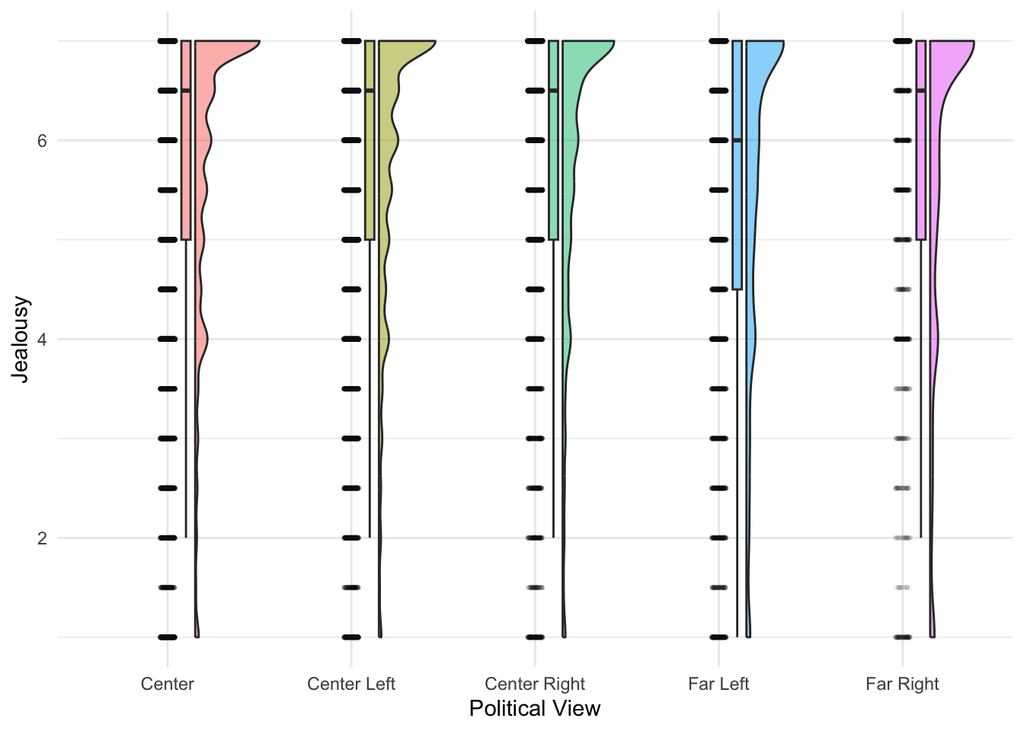

```r
#| label: fig-jealousy
#| fig-cap: "Relationship Jealousy, by Political View." #adds caption under figure
#| fig-width: 8
#| fig-height: 5

ggplot(h1, aes(x = politics, y = jealousy,
                   fill = politics)) +
  geom_rain(alpha = 0.5, point.args = list(alpha = 0.04, size = 0.6)) +
  labs(x = "Political View", y = "Jealousy") +
  theme_minimal() +
  theme(legend.position = "none")
```

## H2. Reported financial prospects will have an influence on daily free time.

### Variables and descriptive statistics

- **Financial Prospects (`financialProspects`):** A single item about future financial prospects. Ranged from 1=Very low, 6=Average, 11=Very high
- **Daily Free Time (`freeTime`):** The amount of daily free time (in minutes) participants reported having

```r
#| label: h2-descriptives
summary(h2[, c("financialProspects", "freeTime")])
```

```
 financialProspects    freeTime
 Min.   : 1.000     Min.   :  0.0
 1st Qu.: 6.000     1st Qu.:122.0
 Median : 6.000     Median :225.0
 Mean   : 6.513     Mean   :218.1
 3rd Qu.: 8.000     3rd Qu.:302.0
 Max.   :11.000     Max.   :360.0
```

### Graph

**?@fig-freeTime** shows the relationship between financial prospects and free time. Points are jittered to make overlapping responses easier to see; the recorded scores are unchanged. The line summarizes the linear trend.

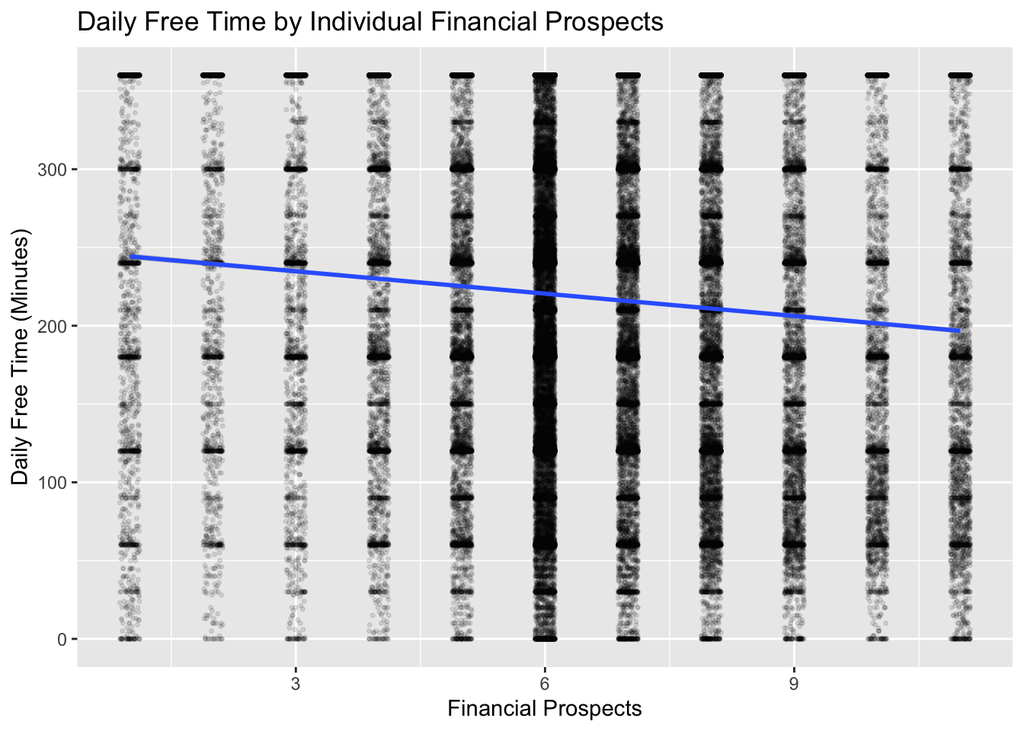

```r
#| label: fig-freeTime
#| fig-cap: "Financial Prospects and Daily Free Time."
#| fig-width: 8
#| fig-height: 5

ggplot(data = h2,
                 aes(x = financialProspects,
                     y = freeTime)) +
  labs(x = "Financial Prospects",
       y = "Daily Free Time (Minutes)",
       title = "Daily Free Time by Individual Financial Prospects") +
  geom_jitter(width = .12, height = 0, alpha = .10, size = .6) +
  geom_smooth(method = "lm")
```

### Observed trend

```r
r <- cor(h2$financialProspects, h2$freeTime, use = "complete.obs")
round(r, 2) #rounds the correlation to 2 decimal places
```

```
[1] -0.09
```

The correlation was -0.09, indicating a weak negative association. Respondents who reported higher financial prospects tended to report lower daily free time.